# 960:365 – Final Project

Nilay Tripathi

12/8/2022

```r
# Load necessary packages
library(bayesrules)
library(bayesplot)
library(rstanarm)
library(tidyverse)
library(tidybayes)
library(broom.mixed)
library(gridExtra)
library(janitor)
```

# Importing and Cleaning Data

## Information About The Data Set

I got this data set from the UCI Machine Learning Repository. The data set’s page can be found [here](https://archive.ics.uci.edu/ml/datasets/automobile). This data set consists of numerous parameters regarding the operation of a car (such as mileage, engine type, fuel type, and a bunch of measurements about the cars). The data set also gives the normalized loss for each car. According to the data set’s page on the UCI Machine Learning Repository, the normalized loss of a vehicle is the loss in payment per insured vehicle year. Furthermore, this value has been scaled for all vehicles of a specific type, to allow for better comparison.

## Importing the Dataset

```r
# Define column names
column_names = c("Symboling", "Normalized_Losses", "Make", "Fuel_Type", "Aspiration", "Num_Doors", "Body_Style", "Drive_Wheels", "Engine_Location", "Wheel_Base", "Length", "Width", "Height", "Curb_Weight", "Engine_Type", "Num_Cylinders", "Engine_Size", "Fuel_System", "Bore", "Stroke", "Compression", "Horsepower", "Peak_RPM", "City_MPG", "Highway_MPG", "Price")

# Read the data
cars_data = read_csv("imports-85.data", col_names = column_names)
# Take a peek at the data
head(cars_data)
```

```
## # A tibble: 6 x 26
##   Symbol~1 Norma~2 Make  Fuel_~3 Aspir~4 Num_D~5 Body_~6 Drive~7 Engin~8 Wheel~9
##      <dbl> <chr>   <chr> <chr>   <chr>   <chr>   <chr>   <chr>   <chr>     <dbl>
## 1        3 ?       alfa~ gas     std     two     conver~ rwd     front      88.6
## 2        3 ?       alfa~ gas     std     two     conver~ rwd     front      88.6
## 3        1 ?       alfa~ gas     std     two     hatchb~ rwd     front      94.5
## 4        2 164     audi  gas     std     four    sedan   fwd     front      99.8
## 5        2 164     audi  gas     std     four    sedan   4wd     front      99.4
## 6        2 ?       audi  gas     std     two     sedan   fwd     front      99.8
## # ... with 16 more variables: Length <dbl>, Width <dbl>, Height <dbl>,
## #   Curb_Weight <dbl>, Engine_Type <chr>, Num_Cylinders <chr>,
## #   Engine_Size <dbl>, Fuel_System <chr>, Bore <chr>, Stroke <chr>,
## #   Compression <dbl>, Horsepower <chr>, Peak_RPM <chr>, City_MPG <dbl>,
## #   Highway_MPG <dbl>, Price <chr>, and abbreviated variable names
## #   1: Symboling, 2: Normalized_Losses, 3: Fuel_Type, 4: Aspiration,
## #   5: Num_Doors, 6: Body_Style, 7: Drive_Wheels, 8: Engine_Location, ...
```

## Data Cleaning

The data in its current form is very messy. We will now clean the data

```r
# The values with a '?' for normalized losses are unknown. Remove them from the data set
cars_df = cars_data %>%
  filter(Normalized_Losses != "?")
head(cars_df)
```

```
## # A tibble: 6 x 26
##   Symbol~1 Norma~2 Make  Fuel_~3 Aspir~4 Num_D~5 Body_~6 Drive~7 Engin~8 Wheel~9
##      <dbl> <chr>   <chr> <chr>   <chr>   <chr>   <chr>   <chr>   <chr>     <dbl>
## 1        2 164     audi  gas     std     four    sedan   fwd     front      99.8
## 2        2 164     audi  gas     std     four    sedan   4wd     front      99.4
## 3        1 158     audi  gas     std     four    sedan   fwd     front     106.
## 4        1 158     audi  gas     turbo   four    sedan   fwd     front     106.
## 5        2 192     bmw   gas     std     two     sedan   rwd     front     101.
## 6        0 192     bmw   gas     std     four    sedan   rwd     front     101.
## # ... with 16 more variables: Length <dbl>, Width <dbl>, Height <dbl>,
## #   Curb_Weight <dbl>, Engine_Type <chr>, Num_Cylinders <chr>,
## #   Engine_Size <dbl>, Fuel_System <chr>, Bore <chr>, Stroke <chr>,
## #   Compression <dbl>, Horsepower <chr>, Peak_RPM <chr>, City_MPG <dbl>,
## #   Highway_MPG <dbl>, Price <chr>, and abbreviated variable names
## #   1: Symboling, 2: Normalized_Losses, 3: Fuel_Type, 4: Aspiration,
## #   5: Num_Doors, 6: Body_Style, 7: Drive_Wheels, 8: Engine_Location, ...
```

```r
# Compare number of observations left
c(nrow(cars_data), nrow(cars_df))
```

```
## [1] 205 164
```

```r
# Overall summary for the different columns
summary(cars_df)
```

```
##    Symboling       Normalized_Losses      Make            Fuel_Type
##  Min.   :-2.0000   Length:164         Length:164         Length:164
##  1st Qu.: 0.0000   Class :character   Class :character   Class :character
##  Median : 1.0000   Mode  :character   Mode  :character   Mode  :character
##  Mean   : 0.7927
##  3rd Qu.: 2.0000
##  Max.   : 3.0000
##   Aspiration         Num_Doors          Body_Style        Drive_Wheels
##  Length:164         Length:164         Length:164         Length:164
##  Class :character   Class :character   Class :character   Class :character
##  Mode  :character   Mode  :character   Mode  :character   Mode  :character
##
##
##
##  Engine_Location      Wheel_Base         Length          Width
##  Length:164         Min.   : 86.60   Min.   :141.1   Min.   :60.3
##  Class :character   1st Qu.: 94.50   1st Qu.:165.7   1st Qu.:64.0
##  Mode  :character   Median : 96.55   Median :172.0   Median :65.4
##                     Mean   : 98.16   Mean   :172.2   Mean   :65.6
##                     3rd Qu.:100.40   3rd Qu.:177.8   3rd Qu.:66.5
##                     Max.   :115.60   Max.   :202.6   Max.   :71.7
##      Height       Curb_Weight   Engine_Type        Num_Cylinders
##  Min.   :49.40   Min.   :1488   Length:164         Length:164
##  1st Qu.:52.00   1st Qu.:2091   Class :character   Class :character
##  Median :54.10   Median :2368   Mode  :character   Mode  :character
##  Mean   :53.77   Mean   :2458
##  3rd Qu.:55.50   3rd Qu.:2786
##  Max.   :59.80   Max.   :4066
##   Engine_Size    Fuel_System            Bore              Stroke
##  Min.   : 61.0   Length:164         Length:164         Length:164
##  1st Qu.: 97.0   Class :character   Class :character   Class :character
##  Median :109.0   Mode  :character   Mode  :character   Mode  :character
##  Mean   :118.0
##  3rd Qu.:131.8
##  Max.   :258.0
##   Compression     Horsepower          Peak_RPM            City_MPG
##  Min.   : 7.00   Length:164         Length:164         Min.   :15.00
##  1st Qu.: 8.70   Class :character   Class :character   1st Qu.:22.00
##  Median : 9.00   Mode  :character   Mode  :character   Median :26.00
##  Mean   :10.13                                         Mean   :26.27
##  3rd Qu.: 9.40                                         3rd Qu.:31.00
##  Max.   :23.00                                         Max.   :49.00
##   Highway_MPG       Price
##  Min.   :18.00   Length:164
##  1st Qu.:28.00   Class :character
##  Median :32.00   Mode  :character
##  Mean   :31.85
##  3rd Qu.:37.00
##  Max.   :54.00
```

```r
# See number of different makes
cars_df %>%
  tabyl(Make)
```

```
##           Make  n     percent
##           audi  4 0.024390244
##            bmw  4 0.024390244
##      chevrolet  3 0.018292683
##          dodge  9 0.054878049
##          honda 13 0.079268293
##         jaguar  1 0.006097561
##          mazda 15 0.091463415
##  mercedes-benz  5 0.030487805
##     mitsubishi 10 0.060975610
##         nissan 18 0.109756098
##         peugot  7 0.042682927
##       plymouth  6 0.036585366
##        porsche  1 0.006097561
##           saab  6 0.036585366
##         subaru 12 0.073170732
##         toyota 31 0.189024390
##     volkswagen  8 0.048780488
##          volvo 11 0.067073171
```

```r
# Make a new column called Average_MPG that is the arithmetic mean of the city and highway MPG
cars_df = cars_df %>%
  mutate(Avg_MPG = (City_MPG + Highway_MPG) / 2)
summary(cars_df$Avg_MPG)
```

```
##    Min. 1st Qu.  Median    Mean 3rd Qu.    Max.
##   17.00   24.50   29.00   29.06   34.00   51.50
```

```r
# Some of the numeric values have character values. We should change this
cars_df = cars_df %>%
  mutate(across(.cols = c(2, 19,20,21,22,23,24,26), as.numeric))
# Summary
summary(cars_df)
```

```
##    Symboling       Normalized_Losses     Make            Fuel_Type
##  Min.   :-2.0000   Min.   : 65       Length:164         Length:164
##  1st Qu.: 0.0000   1st Qu.: 94       Class :character   Class :character
##  Median : 1.0000   Median :115       Mode  :character   Mode  :character
##  Mean   : 0.7927   Mean   :122
##  3rd Qu.: 2.0000   3rd Qu.:150
##  Max.   : 3.0000   Max.   :256
##
##   Aspiration         Num_Doors          Body_Style        Drive_Wheels
##  Length:164         Length:164         Length:164         Length:164
##  Class :character   Class :character   Class :character   Class :character
##  Mode  :character   Mode  :character   Mode  :character   Mode  :character
##
##
##
##
##  Engine_Location      Wheel_Base         Length          Width
##  Length:164         Min.   : 86.60   Min.   :141.1   Min.   :60.3
##  Class :character   1st Qu.: 94.50   1st Qu.:165.7   1st Qu.:64.0
##  Mode  :character   Median : 96.55   Median :172.0   Median :65.4
##                     Mean   : 98.16   Mean   :172.2   Mean   :65.6
##                     3rd Qu.:100.40   3rd Qu.:177.8   3rd Qu.:66.5
##                     Max.   :115.60   Max.   :202.6   Max.   :71.7
##
##      Height       Curb_Weight   Engine_Type        Num_Cylinders
##  Min.   :49.40   Min.   :1488   Length:164         Length:164
##  1st Qu.:52.00   1st Qu.:2091   Class :character   Class :character
##  Median :54.10   Median :2368   Mode  :character   Mode  :character
##  Mean   :53.77   Mean   :2458
##  3rd Qu.:55.50   3rd Qu.:2786
##  Max.   :59.80   Max.   :4066
##
##   Engine_Size    Fuel_System             Bore           Stroke
##  Min.   : 61.0   Length:164         Min.   :2.540   Min.   :2.070
##  1st Qu.: 97.0   Class :character   1st Qu.:3.050   1st Qu.:3.107
##  Median :109.0   Mode  :character   Median :3.270   Median :3.270
##  Mean   :118.0                      Mean   :3.298   Mean   :3.237
##  3rd Qu.:131.8                      3rd Qu.:3.550   3rd Qu.:3.410
##  Max.   :258.0                      Max.   :3.940   Max.   :4.170
##                                     NA's   :4       NA's   :4
##   Compression      Horsepower        Peak_RPM       City_MPG
##  Min.   : 7.00   Min.   : 48.00   Min.   :4150   Min.   :15.00
##  1st Qu.: 8.70   1st Qu.: 69.00   1st Qu.:4800   1st Qu.:22.00
##  Median : 9.00   Median : 91.00   Median :5200   Median :26.00
##  Mean   :10.13   Mean   : 96.21   Mean   :5138   Mean   :26.27
##  3rd Qu.: 9.40   3rd Qu.:114.00   3rd Qu.:5500   3rd Qu.:31.00
##  Max.   :23.00   Max.   :200.00   Max.   :6600   Max.   :49.00
##
##   Highway_MPG        Price          Avg_MPG
##  Min.   :18.00   Min.   : 5118   Min.   :17.00
##  1st Qu.:28.00   1st Qu.: 7446   1st Qu.:24.50
##  Median :32.00   Median : 9268   Median :29.00
##  Mean   :31.85   Mean   :11467   Mean   :29.06
##  3rd Qu.:37.00   3rd Qu.:14559   3rd Qu.:34.00
##  Max.   :54.00   Max.   :35056   Max.   :51.50
##
```

```r
# Extra NA values have been identified in column 20. Remove them
cars_df = cars_df %>%
  filter(!is.na(Stroke))
summary(cars_df)
```

```
##    Symboling       Normalized_Losses     Make            Fuel_Type
##  Min.   :-2.0000   Min.   : 65.0     Length:160         Length:160
##  1st Qu.: 0.0000   1st Qu.: 94.0     Class :character   Class :character
##  Median : 1.0000   Median :114.0     Mode  :character   Mode  :character
##  Mean   : 0.7375   Mean   :121.3
##  3rd Qu.: 2.0000   3rd Qu.:148.0
##  Max.   : 3.0000   Max.   :256.0
##   Aspiration         Num_Doors          Body_Style        Drive_Wheels
##  Length:160         Length:160         Length:160         Length:160
##  Class :character   Class :character   Class :character   Class :character
##  Mode  :character   Mode  :character   Mode  :character   Mode  :character
##
##
##
##  Engine_Location      Wheel_Base         Length          Width
##  Length:160         Min.   : 86.60   Min.   :141.1   Min.   :60.3
##  Class :character   1st Qu.: 94.50   1st Qu.:165.5   1st Qu.:64.0
##  Mode  :character   Median : 96.90   Median :172.2   Median :65.4
##                     Mean   : 98.24   Mean   :172.3   Mean   :65.6
##                     3rd Qu.:100.60   3rd Qu.:177.8   3rd Qu.:66.5
##                     Max.   :115.60   Max.   :202.6   Max.   :71.7
##      Height       Curb_Weight   Engine_Type        Num_Cylinders
##  Min.   :49.40   Min.   :1488   Length:160         Length:160
##  1st Qu.:52.00   1st Qu.:2073   Class :character   Class :character
##  Median :54.10   Median :2338   Mode  :character   Mode  :character
##  Mean   :53.88   Mean   :2459
##  3rd Qu.:55.50   3rd Qu.:2809
##  Max.   :59.80   Max.   :4066
##   Engine_Size    Fuel_System             Bore           Stroke
##  Min.   : 61.0   Length:160         Min.   :2.540   Min.   :2.070
##  1st Qu.: 97.0   Class :character   1st Qu.:3.050   1st Qu.:3.107
##  Median :110.0   Mode  :character   Median :3.270   Median :3.270
##  Mean   :119.1                      Mean   :3.298   Mean   :3.237
##  3rd Qu.:134.5                      3rd Qu.:3.550   3rd Qu.:3.410
##  Max.   :258.0                      Max.   :3.940   Max.   :4.170
##   Compression      Horsepower        Peak_RPM       City_MPG
##  Min.   : 7.00   Min.   : 48.00   Min.   :4150   Min.   :15.00
##  1st Qu.: 8.70   1st Qu.: 69.00   1st Qu.:4800   1st Qu.:23.00
##  Median : 9.00   Median : 88.00   Median :5200   Median :26.00
##  Mean   :10.15   Mean   : 95.88   Mean   :5116   Mean   :26.51
##  3rd Qu.: 9.40   3rd Qu.:114.00   3rd Qu.:5500   3rd Qu.:31.00
##  Max.   :23.00   Max.   :200.00   Max.   :6600   Max.   :49.00
##   Highway_MPG        Price          Avg_MPG
##  Min.   :18.00   Min.   : 5118   Min.   :17.00
##  1st Qu.:28.00   1st Qu.: 7384   1st Qu.:25.25
##  Median :32.00   Median : 9164   Median :29.00
##  Mean   :32.07   Mean   :11428   Mean   :29.29
##  3rd Qu.:37.00   3rd Qu.:14559   3rd Qu.:34.00
##  Max.   :54.00   Max.   :35056   Max.   :51.50
```

# Building a Model

We will build a model for `Normalized_Losses`. We will utilize the predictors `price` along with the categorical predictor `Aspiration`.

## Initial Plotting

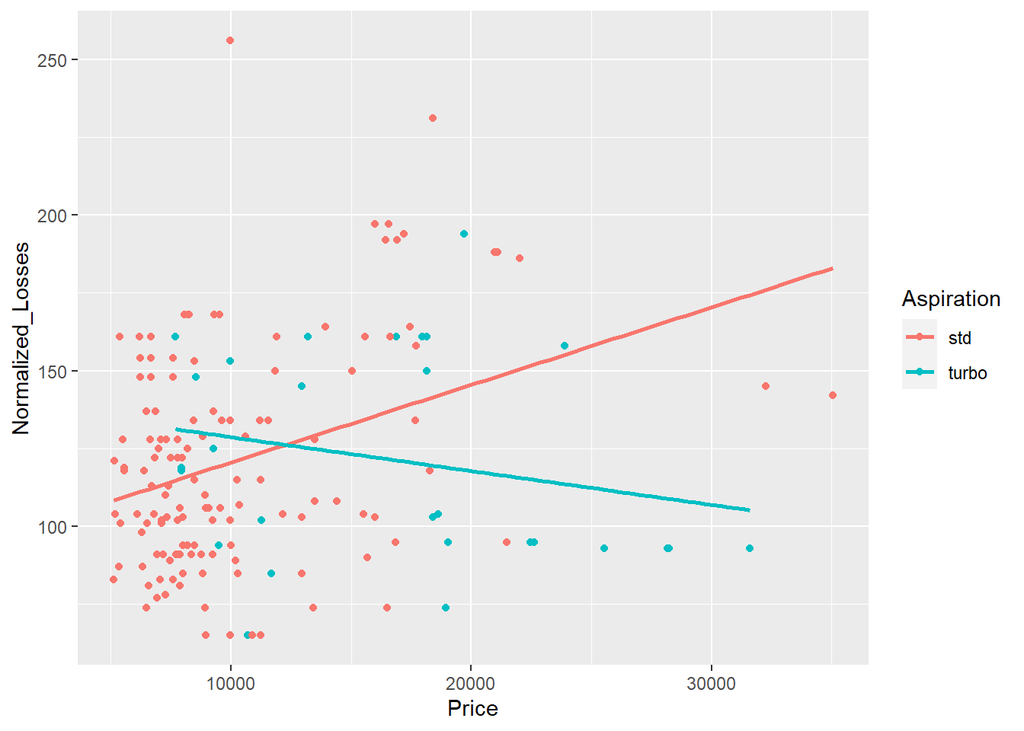

```r
ggplot(data = cars_df, aes(x = Price, y = Normalized_Losses, color = Aspiration)) +
  geom_point() +
  geom_smooth(method = "lm", se = FALSE)
```

```r
# Summary of the values of the cars by fuel type
cars_df %>%
  group_by(Aspiration) %>%
  summarize(avg = mean(Normalized_Losses),
            n = n())
```

```
## # A tibble: 2 x 3
##   Aspiration   avg     n
##   <chr>      <dbl> <int>
## 1 std         121.   132
## 2 turbo       121.    28
```

The plot above analyzes the relationship between `Normalized_Losses` and `Price`. The relationship doesn’t appear too strong in the model. Additionally, there seems to be a noticeable interaction effect since the slopes of the lines for std Aspiration and turbo Aspiration have opposite signs.

In light of these observations, we will fit two models: one with an interaction term and one without. We will then compare these two models using cross validation and expected log predictive density (ELPD).

## Fitting the No-Interaction Model

Here we will fit the model without interaction effects.

```r
no_interaction = stan_glm(
  Normalized_Losses ~ Price + Aspiration,
  data = cars_df, family = gaussian,
  prior_intercept = normal(120, 5, autoscale = TRUE),
  prior = normal(0, 2.5, autoscale = TRUE),
  prior_aux = exponential(1, autoscale = TRUE),
  chains = 4, iter = 5000*2, seed = 12345
)
```

### Prior Summary

Here is an overview of the priors that were selected initially and how the `stan_glm` function adjusted them. The intercept prior was chosen from the output of the `summarize` function under the graph.

```r
prior_summary(no_interaction)
```

```
## Priors for model 'no_interaction'
## ------
## Intercept (after predictors centered)
##   Specified prior:
##     ~ normal(location = 120, scale = 5)
##   Adjusted prior:
##     ~ normal(location = 120, scale = 178)
##
## Coefficients
##   Specified prior:
##     ~ normal(location = [0,0], scale = [2.5,2.5])
##   Adjusted prior:
##     ~ normal(location = [0,0], scale = [  0.015,233.514])
##
## Auxiliary (sigma)
##   Specified prior:
##     ~ exponential(rate = 1)
##   Adjusted prior:
##     ~ exponential(rate = 0.028)
## ------
## See help('prior_summary.stanreg') for more details
```

### MCMC Diagnostics

Here are the MCMC diagnostics for this model

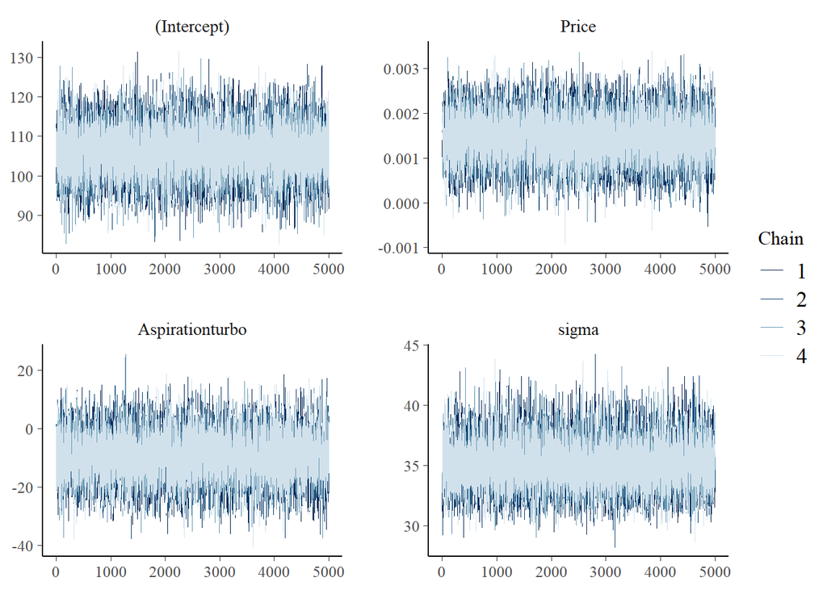

```r
# Trace plots
mcmc_trace(no_interaction, size = 0.1)
```

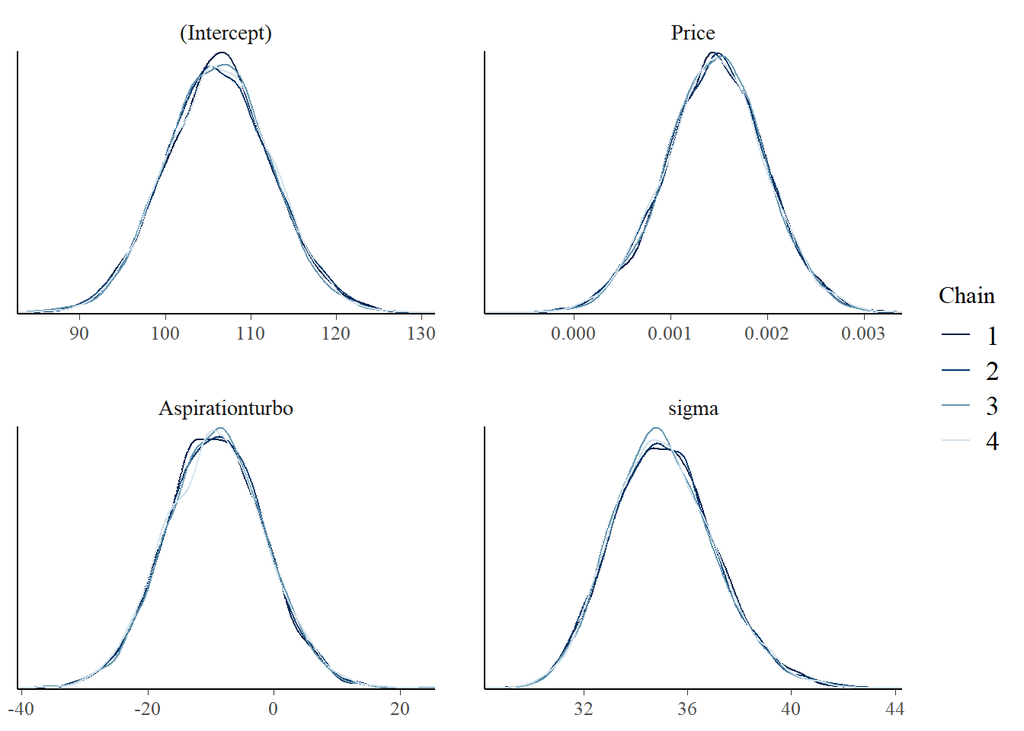

```r
# Density overlays
mcmc_dens_overlay(no_interaction)
```

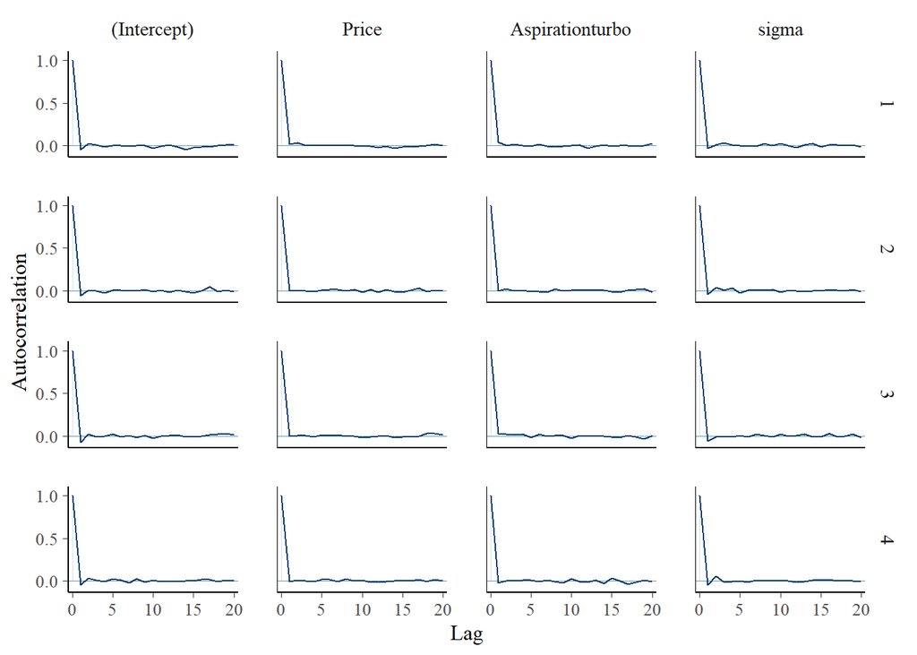

```r
# Autocorrelation plots
mcmc_acf(no_interaction)
```

```r
# Effective Sample Size ratio
neff_ratio(no_interaction)
```

```
##     (Intercept)           Price Aspirationturbo           sigma
##         1.05815         0.94730         0.93090         1.02640
```

```r
# Rhat
rhat(no_interaction)
```

```
##     (Intercept)           Price Aspirationturbo           sigma
##       0.9999244       1.0000012       1.0003258       1.0000693
```

All of these diagnostics show promising results of the chain. The trace plots exhibit good random scatter, the density overlays are all very similar, and the autocorrelation in the chains quickly approaches 0. Additionally, the effective sample size ratios are all high and the values of $\hat{R}$ are all less than 1.01, which indicates that the chains have mixed well.

### Numerical Output

Generate the numerical output of the model using the `tidy` function.

```r
tidy(no_interaction, effects = c("fixed", "aux"), conf.int = TRUE, conf.level = 0.80)
```

```
## # A tibble: 5 x 5
##   term             estimate std.error   conf.low conf.high
##   <chr>               <dbl>     <dbl>      <dbl>     <dbl>
## 1 (Intercept)     106.       6.18      98.2      114.
## 2 Price             0.00147  0.000512   0.000788   0.00212
## 3 Aspirationturbo  -9.30     7.87     -19.4        0.757
## 4 sigma            35.0      1.99      32.6       37.7
## 5 mean_PPD        121.       3.92     116.       126.
```

### Interpreting the Coefficients

We will now interpret the various coefficients from the model

- `(Intercept)`: for a typical std aspiration car that cost $0, the estimated normalized loss is 106. We should note that this intercept doesn’t make sense since very few (if any) cars will cost $0. So the intercept is just here for mathematical reasons.
- `Price`: for a unit increase in price, the normalized loss will increase by roughly 0.00147. Since this is a no-interaction model, this is the common slope for both lines and so this increase is the same for both std aspiration cars and turbo aspiration cars.
- `Aspirationturbo`: for two cars that were the same price, the normalized loss for a turbo aspiration car is about -9.30 less than that for a std aspiration car.
- `sigma`: this is the estimated variation in possible normalized losses for cars that have the same price.

The output indicates that `Price` is significant (although barely since the coefficients are still pretty close to 0). The categorical variable `Aspiration` does not appear to be significant. We will now calculate the probabilities of these coefficients

### Assessing the Regression Coefficients

We will find the probability that the regression coefficient of `Price` is greater than 0 in our posterior prediction.

```r
no_interaction_df = as.data.frame(no_interaction, include = FALSE)
head(no_interaction_df)
```

```
##   (Intercept)        Price Aspirationturbo    sigma
## 1   107.79186 0.0013981249       -8.226944 31.17148
## 2   113.16627 0.0006371871        1.339551 34.92625
## 3   106.54654 0.0018000444      -17.285537 34.38194
## 4   109.13819 0.0016905068      -19.896218 34.81984
## 5    98.16627 0.0019386250      -13.518548 34.55718
## 6   105.38729 0.0009179619       -3.516843 34.59504
```

```r
# Probability that Price coefficient is greater than 0
no_interaction_df %>%
  mutate(regGreaterThan0 = (Price > 0)) %>%
  tabyl(regGreaterThan0)
```

```
##  regGreaterThan0     n percent
##            FALSE    63 0.00315
##             TRUE 19937 0.99685
```

```r
# Probability that Aspirationturbo coefficient is greater than 0
no_interaction_df %>%
  mutate(aspirationGreaterThan0 = (Aspirationturbo > 0)) %>%
  tabyl(aspirationGreaterThan0)
```

```
##  aspirationGreaterThan0     n percent
##                   FALSE 17657 0.88285
##                    TRUE  2343 0.11715
```

From the output, we see that the probability of the `Price` being greater than 0 is 0.996, which indicates the `Price` is significant, as indicated by the posterior model. However, in this model, the probability that `Aspirationturbo` is greater than 0 is only 0.117 while the probability that it is negative is 0.883. This indicates that this coefficient is most likely negative under the posterior model. As the earlier `tidy` output suggested, however, this coefficient isn’t significant in this model.

### Simulating the Posterior Model

We will now simulate 100 possible models from the posterior line.

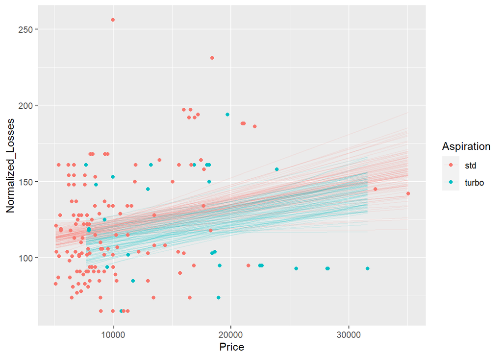

```r
cars_df %>%
  add_fitted_draws(no_interaction, n = 100) %>%
  ggplot(aes(x = Price, y = Normalized_Losses, color = Aspiration)) +
  geom_line(aes(y = .value, group = paste(Aspiration, .draw)), alpha = .1) +
  geom_point(data = cars_df)
```

All lines indicate that there is a positive association between price and normalized losses. Interestingly, the slope is also positive for turbo cars while the exploratory plot indicated that the correlation is negative. This reflects the fact that the `Aspiration` predictor is not significant in this model.

### Prediction Using This Model

We will now predict the normalized loss of a car which cost $15,000. The code and the corresponding graphs are shown below

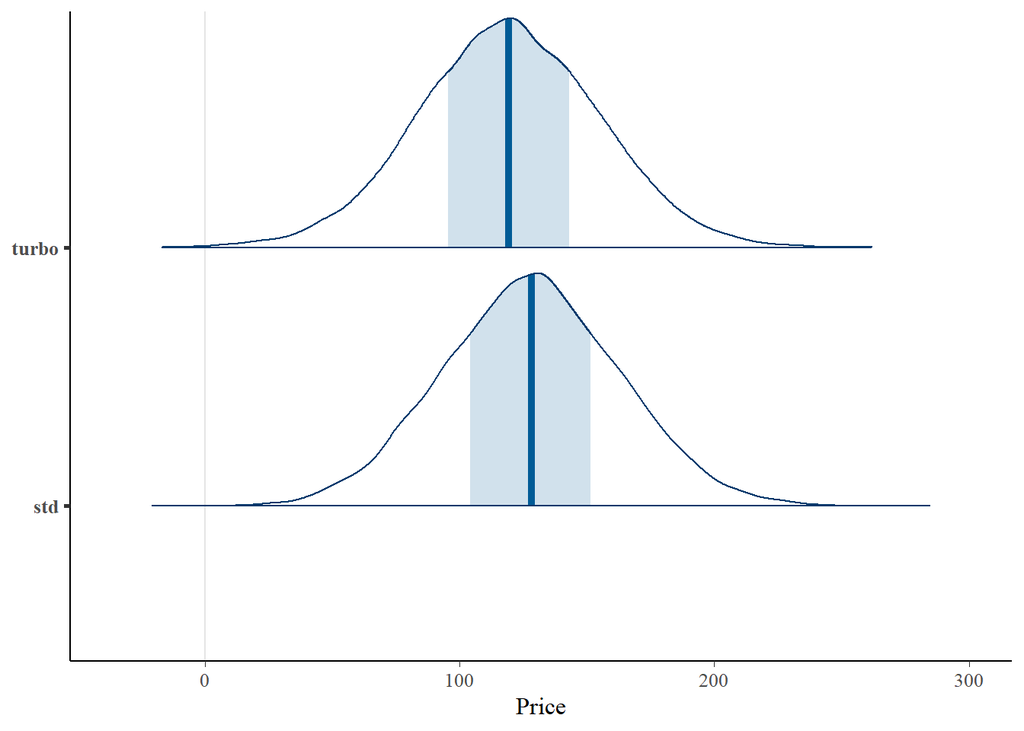

```r
set.seed(12345)

# Simulate the predictions
price_15000_prediction_nointeract = posterior_predict(
  no_interaction,
  newdata = data.frame(Price = c(15000, 15000),
                       Aspiration = c("std", "turbo"))
)

# Plot the predictions
mcmc_areas(price_15000_prediction_nointeract) +
  ggplot2::scale_y_discrete(labels = c("std", "turbo")) +
  xlab("Price")
```

## Fitting the Interaction Model

The graph indicates that there could be an interaction between these models. Let’s fit an interaction model to see if it is better than the non-interaction one.

```r
interaction_model = stan_glm(
  Normalized_Losses ~ Aspiration + Price + Aspiration:Price,
  data = cars_df, family = gaussian,
  prior_intercept = normal(120, 5, autoscale = TRUE),
  prior = normal(0, 2.5, autoscale = TRUE),
  prior_aux = exponential(1, autoscale = TRUE),
  chains = 4, iter = 5000*2, seed = 12345
)
```

### Prior Summary

Here is the prior model that I initially chose and how the `stan_glm` function adjusted them. The intercept prior is the same as that of the interaction model.

```r
prior_summary(interaction_model)
```

```
## Priors for model 'interaction_model'
## ------
## Intercept (after predictors centered)
##   Specified prior:
##     ~ normal(location = 120, scale = 5)
##   Adjusted prior:
##     ~ normal(location = 120, scale = 178)
##
## Coefficients
##   Specified prior:
##     ~ normal(location = [0,0,0], scale = [2.5,2.5,2.5])
##   Adjusted prior:
##     ~ normal(location = [0,0,0], scale = [233.514,  0.015,  0.013])
##
## Auxiliary (sigma)
##   Specified prior:
##     ~ exponential(rate = 1)
##   Adjusted prior:
##     ~ exponential(rate = 0.028)
## ------
## See help('prior_summary.stanreg') for more details
```

### MCMC Diagnostics

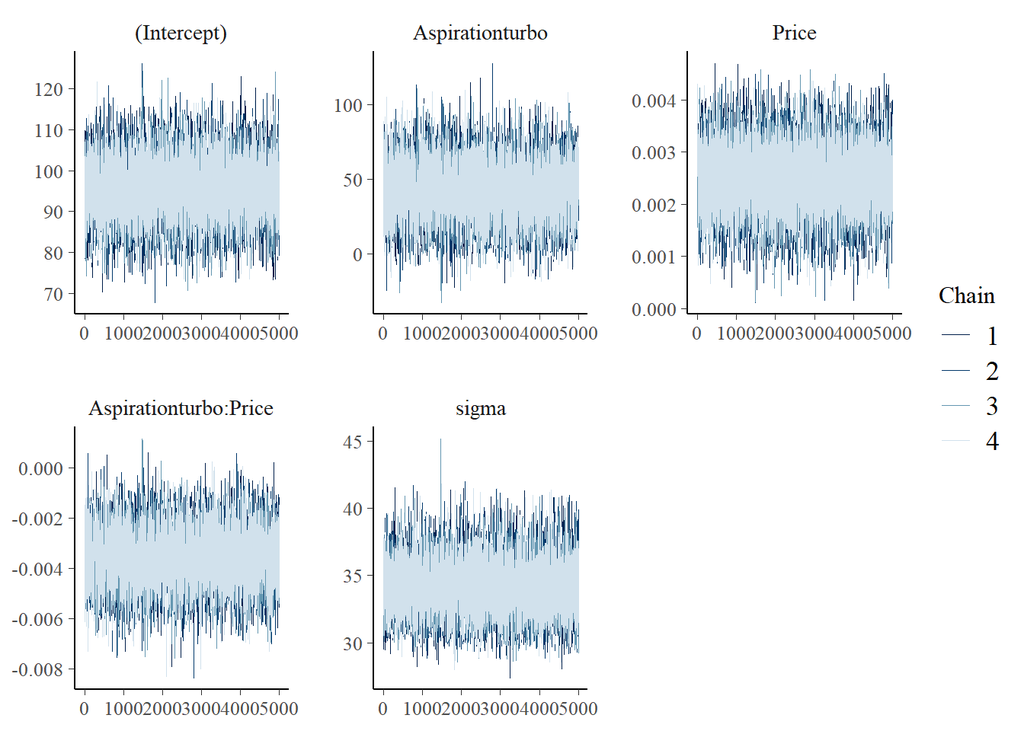

```r
# Trace plots
mcmc_trace(interaction_model, size = 0.1)
```

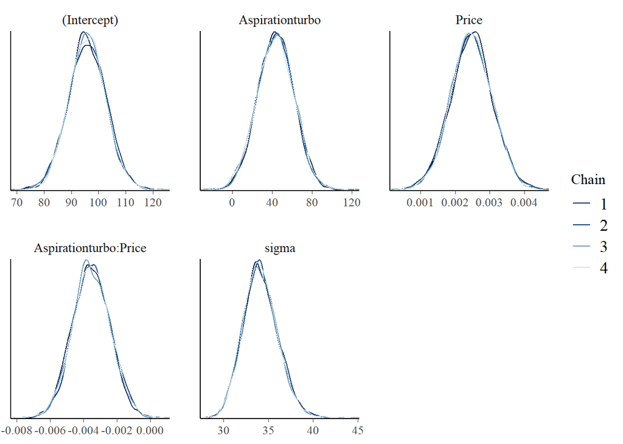

```r
# Density overlays
mcmc_dens_overlay(interaction_model)
```

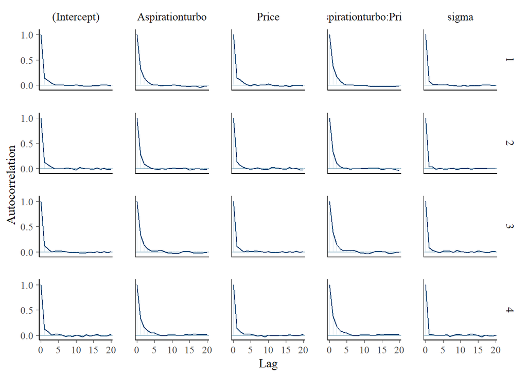

```r
# Autocorrelation plots
mcmc_acf(interaction_model)
```

```r
# Effective sample size ratio
neff_ratio(interaction_model)
```

```
##           (Intercept)       Aspirationturbo                 Price
##               0.66455               0.46590               0.65090
## Aspirationturbo:Price                 sigma
##               0.42935               0.83565
```

```r
# Rhat value
rhat(interaction_model)
```

```
##           (Intercept)       Aspirationturbo                 Price
##              1.000134              1.000386              1.000140
## Aspirationturbo:Price                 sigma
##              1.000532              1.000070
```

The diagnostics show that the chains have mixed well and are a good approximation of the posterior distribution. The trace plots display the desired random scatter, the density overlays are all fairly similar and consistent, and the autocorrelation plots indicate that the autocorrelation in the chains quickly approach 0. Additionally, the effective sample size ratios are all greater than 0.1 and the $\hat{R}$ values are all less than 1.01, which indicates the chains have mixed well.

### Numerical Output

Here is the `tidy` summary for this model.

```r
tidy(interaction_model, effects = c("fixed", "aux"), conf.int = TRUE, conf.level = 0.80)
```

```
## # A tibble: 6 x 5
##   term                   estimate std.error  conf.low conf.high
##   <chr>                     <dbl>     <dbl>     <dbl>     <dbl>
## 1 (Intercept)            95.8      6.87      86.9     105.
## 2 Aspirationturbo        43.4     18.6       19.4      67.0
## 3 Price                   0.00247  0.000595   0.00171   0.00325
## 4 Aspirationturbo:Price  -0.00354  0.00113   -0.00495  -0.00208
## 5 sigma                  34.0      1.94      31.7      36.7
## 6 mean_PPD              121.       3.84     116.      126.
```

Since all of the 80% credible intervals do not contain 0 for any of the coefficients, we have that all these coefficients are significant in this model.

### Interpretation of Coefficients

Here are the interpretation of the coefficients from the interaction model

- `(Intercept)`: This is the intercept of the lines for std aspiration cars. The normalized loss for a std aspiration car with price $0 is 95.8. Similar to the no-interaction model, this intercept doesn’t make sense in this context.
- `Aspirationturbo`: This is the difference in intercepts between std aspiration cars and turbo aspiration cars. For two cars with the same price, the difference in intercepts is 43.4. - `Price`: This is the slope of the std aspiration cars. For a unit increase in Price, the normalized loss for a std car will increase by roughly 0.00247.
- `Aspirationturbo:Price`: This is the difference in slopes between std and turbo aspiration cars. The difference in slopes between turbo and std aspiration cars is -0.00354, so this represents the difference in the rate of change of normalized loss for a unit increase in price.
- `sigma`: This is the variability associated with the observations of normalized losses for a fixed value of Price.

### Simulating The Posterior Model

We will now simulate 100 draws from this posterior model.

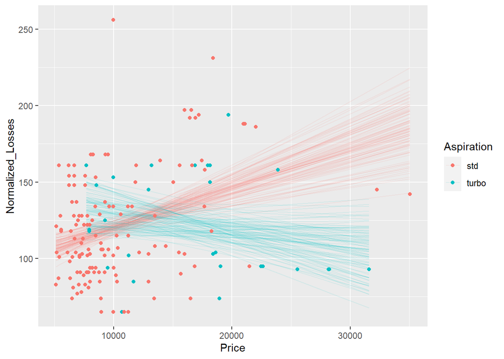

```r
cars_df %>%
  add_fitted_draws(interaction_model, n = 100) %>%
  ggplot(aes(x = Price, y = Normalized_Losses, color = Aspiration)) +
  geom_line(aes(y = .value, group = paste(Aspiration, .draw)), alpha = .1) +
  geom_point(data = cars_df)
```

The posterior draws for the interaction model highlight the difference in slopes between turbo and std cars. However, the draws have considerable variation, which is reflective of the weak overall relationship between the predictors.

### Posterior Prediction Using This Model

We will now use this model to predict the normalized loss of a $15,000 car. The code and corresponding graph are shown below

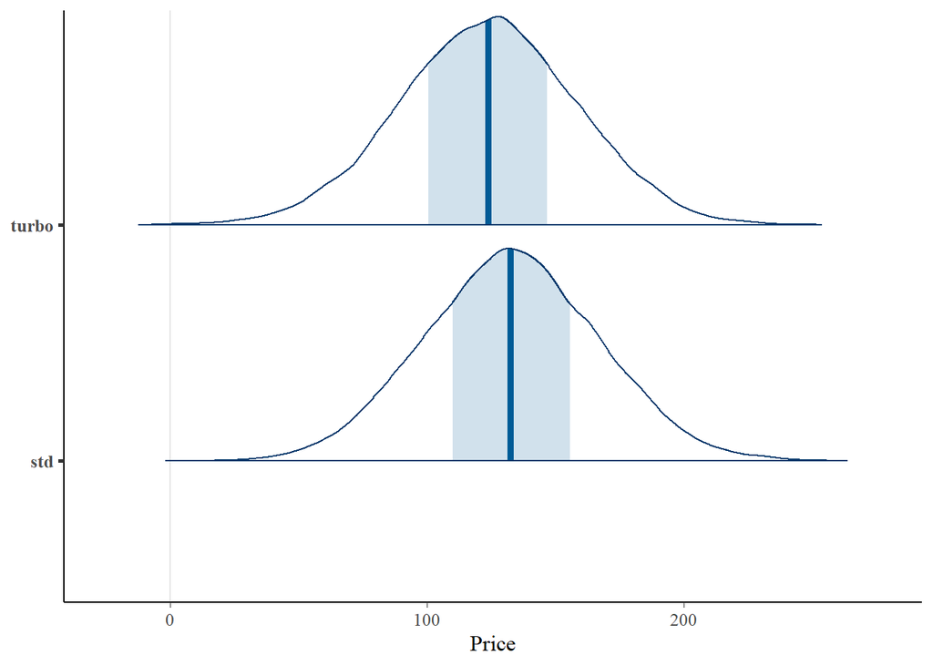

```r
set.seed(12345)

# Simulate the predictions
price_15000_prediction_interaction = posterior_predict(
  interaction_model,
  newdata = data.frame(Price = c(15000, 15000),
                       Aspiration = c("std", "turbo"))
)

# Plot the predictions
mcmc_areas(price_15000_prediction_interaction) +
  ggplot2::scale_y_discrete(labels = c("std", "turbo")) +
  xlab("Price")
```

# Comparing the Models

Now we will compare the interaction and no-interaction models using cross validation and ELPD techniques.

## Cross Validation

We will employ 10-fold cross validation to compare the models

```r
set.seed(12345)

# No interaction model
no_interact_cv = prediction_summary_cv(model = no_interaction, data = cars_df, k = 10)

# Interaction model
interaction_cv = prediction_summary_cv(model = interaction_model, data = cars_df, k = 10)

# Show summaries
no_interact_cv$cv
```

```
##        mae mae_scaled within_50 within_95
## 1 24.27108   0.682494   0.41875    0.9875
```

```r
interaction_cv$cv
```

```
##       mae mae_scaled within_50 within_95
## 1 25.8677  0.7449496   0.48125   0.98125
```

## Expected Log-Predictive Density (ELPD)

```r
# Find the ELPD's for the two models
no_interact_loo = loo(no_interaction)
interaction_loo = loo(interaction_model)

# Print out estimates
no_interact_loo$estimates
```

```
##            Estimate         SE
## elpd_loo -798.40452  9.9904517
## p_loo       4.30965  0.8639664
## looic    1596.80905 19.9809034
```

```r
interaction_loo$estimates
```

```
##             Estimate        SE
## elpd_loo -794.346043 10.421015
## p_loo       5.119785  1.014826
## looic    1588.692086 20.842030
```

```r
# Compare the models
loo_compare(no_interact_loo, interaction_loo)
```

```
##                   elpd_diff se_diff
## interaction_model  0.0       0.0
## no_interaction    -4.1       3.0
```

## Choosing The Model

From the cross validation results, we have the MAE (median absolute error) for the interaction model is larger than that of the no interaction model. However, when comparing the ELPDs from the `loo` comparison, we find that the interaction model has a higher ELPD, meaning it is better than the no interaction model.

From the analysis, I will choose the interaction model since all regressors are significant in the model and it matches the data visualization. However, there are some concerns in this model. The higher MAE from the cross validation is one such concern and we should be wary to base predictions off of this model. However, the general trend indicated by the exploratory analysis indicates the second model will be a good fit. The coefficients are significant and it has a higher ELPD than the first model.

# Credits and Honor Pledge

## Credits

- I found the data set on the UCI Machine Learning Repository. The data set’s page on the UCI Machine Learning Repository can be found [here](https://archive.ics.uci.edu/ml/datasets/automobile).

## Honor Pledge

> “On my honor, I have neither received nor given any unauthorized assistance on this project”  
> - Nilay Tripathi